# W3cubDocs

**`get_xdata(self, orig=True)` [[source]](https://matplotlib.org/3.1.1/_modules/matplotlib/lines.html#Line2D.get_xdata)**

Return the xdata.

If *orig* is *True*, return the original data, else the processed data.

**`get_xydata(self)` [[source]](https://matplotlib.org/3.1.1/_modules/matplotlib/lines.html#Line2D.get_xydata)**

Return the *xy* data as a Nx2 numpy array.

**`get_ydata(self, orig=True)` [[source]](https://matplotlib.org/3.1.1/_modules/matplotlib/lines.html#Line2D.get_ydata)**

Return the ydata.

If *orig* is *True*, return the original data, else the processed data.

**`is_dashed(self)` [[source]](https://matplotlib.org/3.1.1/_modules/matplotlib/lines.html#Line2D.is_dashed)**

Return whether line has a dashed linestyle.

See also `set_linestyle`.

**`lineStyles = {'': '_draw_nothing', ' ': '_draw_nothing', '-': '_draw_solid', '--': '_draw_dashed', '-.': '_draw_dash_dot', ':': '_draw_dotted', 'None': '_draw_nothing'}`**

**`markers = {'.': 'point', ',': 'pixel', 'o': 'circle', 'v': 'triangle_down', '^': 'triangle_up', '<': 'triangle_left', '>': 'triangle_right', '1': 'tri_down', '2': 'tri_up', '3': 'tri_left', '4': 'tri_right', '8': 'octagon', 's': 'square', 'p': 'pentagon', '*': 'star', 'h': 'hexagon1', 'H': 'hexagon2', '+': 'plus', 'x': 'x', 'D': 'diamond', 'd': 'thin_diamond', '|': 'vline', '_': 'hline', 'P': 'plus_filled', 'X': 'x_filled', 0: 'tickleft', 1: 'tickright', 2: 'tickup', 3: 'tickdown', 4: 'caretleft', 5: 'caretright', 6: 'caretup', 7: 'caretdown', 8: 'caretleftbase', 9: 'caretrightbase', 10: 'caretupbase', 11: 'caretdownbase', 'None': 'nothing', None: 'nothing', ' ': 'nothing', '': 'nothing'}`**

**`recache(self, always=False)` [[source]](https://matplotlib.org/3.1.1/_modules/matplotlib/lines.html#Line2D.recache)**

**`recache_always(self)` [[source]](https://matplotlib.org/3.1.1/_modules/matplotlib/lines.html#Line2D.recache_always)**

**`set_aa(self, b)`**

Alias for `set_antialiased`.

**`set_antialiased(self, b)` [[source]](https://matplotlib.org/3.1.1/_modules/matplotlib/lines.html#Line2D.set_antialiased)**

Set whether to use antialiased rendering.

| Parameters: | **`b : bool`** |
| --- | --- |

**`set_c(self, color)`**

Alias for `set_color`.

**`set_color(self, color)` [[source]](https://matplotlib.org/3.1.1/_modules/matplotlib/lines.html#Line2D.set_color)**

Set the color of the line.

| Parameters: | **`color : color`** |
| --- | --- |

**`set_dash_capstyle(self, s)` [[source]](https://matplotlib.org/3.1.1/_modules/matplotlib/lines.html#Line2D.set_dash_capstyle)**

Set the cap style for dashed lines.

| Parameters: | **`s : {'butt', 'round', 'projecting'}`** |
| --- | --- |

**`set_dash_joinstyle(self, s)` [[source]](https://matplotlib.org/3.1.1/_modules/matplotlib/lines.html#Line2D.set_dash_joinstyle)**

Set the join style for dashed lines.

| Parameters: | **`s : {'miter', 'round', 'bevel'}`** For examples see [Join styles and cap styles](https://matplotlib.org/3.1.1/gallery/lines_bars_and_markers/joinstyle.html). |
| --- | --- |

**`set_dashes(self, seq)` [[source]](https://matplotlib.org/3.1.1/_modules/matplotlib/lines.html#Line2D.set_dashes)**

Set the dash sequence.

The dash sequence is a sequence of floats of even length describing the length of dashes and spaces in points.

For example, (5, 2, 1, 2) describes a sequence of 5 point and 1 point dashes separated by 2 point spaces.

| Parameters: | **`seq : sequence of floats (on/off ink in points) or (None, None)`** If *seq* is empty or `(None, None)`, the linestyle will be set to solid. |
| --- | --- |

**`set_data(self, *args)` [[source]](https://matplotlib.org/3.1.1/_modules/matplotlib/lines.html#Line2D.set_data)**

Set the x and y data.

| Parameters: | **`*args : (2, N) array or two 1D arrays`** |
| --- | --- |

**`set_drawstyle(self, drawstyle)` [[source]](https://matplotlib.org/3.1.1/_modules/matplotlib/lines.html#Line2D.set_drawstyle)**

Set the drawstyle of the plot.

The drawstyle determines how the points are connected.

Parameters:

**`drawstyle : {'default', 'steps', 'steps-pre', 'steps-mid', 'steps-post'}, default: 'default'`**

For 'default', the points are connected with straight lines.

The steps variants connect the points with step-like lines, i.e. horizontal lines with vertical steps. They differ in the location of the step:

- 'steps-pre': The step is at the beginning of the line segment, i.e. the line will be at the y-value of point to the right.
- 'steps-mid': The step is halfway between the points.
- 'steps-post: The step is at the end of the line segment, i.e. the line will be at the y-value of the point to the left.
- 'steps' is equal to 'steps-pre' and is maintained for backward-compatibility.

**`set_ds(self, drawstyle)`**

Alias for `set_drawstyle`.

**`set_fillstyle(self, fs)` [[source]](https://matplotlib.org/3.1.1/_modules/matplotlib/lines.html#Line2D.set_fillstyle)**

Set the marker fill style.

Parameters:

**`fs : {'full', 'left', 'right', 'bottom', 'top', 'none'}`**

Possible values:

- 'full': Fill the whole marker with the *markerfacecolor*.
- 'left', 'right', 'bottom', 'top': Fill the marker half at the given side with the *markerfacecolor*. The other half of the marker is filled with *markerfacecoloralt*.
- 'none': No filling.

For examples see [Marker filling-styles](https://matplotlib.org/3.1.1/gallery/lines_bars_and_markers/marker_fillstyle_reference.html).

**`set_linestyle(self, ls)` [[source]](https://matplotlib.org/3.1.1/_modules/matplotlib/lines.html#Line2D.set_linestyle)**

Set the linestyle of the line.

Parameters:

**`ls : {'-', '--', '-.', ':', '', (offset, on-off-seq), ...}`**

Possible values:

- A string:

  | Linestyle | Description |
  | --- | --- |
  | `'-'` or `'solid'` | solid line |
  | `'--'` or `'dashed'` | dashed line |
  | `'-.'` or `'dashdot'` | dash-dotted line |
  | `':'` or `'dotted'` | dotted line |
  | `'None'` or `' '` or `''` | draw nothing |

  Optionally, the string may be preceded by a drawstyle, e.g. `'steps--'`. See `set_drawstyle()` for details.
- Alternatively a dash tuple of the following form can be provided:

  ```
  (offset, onoffseq)
  ```

  where `onoffseq` is an even length tuple of on and off ink in points. See also `set_dashes()`.

**`set_linewidth(self, w)` [[source]](https://matplotlib.org/3.1.1/_modules/matplotlib/lines.html#Line2D.set_linewidth)**

Set the line width in points.

| Parameters: | **`w : float`** |
| --- | --- |

**`set_ls(self, ls)`**

Alias for `set_linestyle`.

**`set_lw(self, w)`**

Alias for `set_linewidth`.

**`set_marker(self, marker)` [[source]](https://matplotlib.org/3.1.1/_modules/matplotlib/lines.html#Line2D.set_marker)**

Set the line marker.

| Parameters: | **`marker : marker style`** See `markers` for full description of possible arguments. |
| --- | --- |

**`set_markeredgecolor(self, ec)` [[source]](https://matplotlib.org/3.1.1/_modules/matplotlib/lines.html#Line2D.set_markeredgecolor)**

Set the marker edge color.

| Parameters: | **`ec : color`** |
| --- | --- |

**`set_markeredgewidth(self, ew)` [[source]](https://matplotlib.org/3.1.1/_modules/matplotlib/lines.html#Line2D.set_markeredgewidth)**

Set the marker edge width in points.

| Parameters: | **`ew : float`** |
| --- | --- |

**`set_markerfacecolor(self, fc)` [[source]](https://matplotlib.org/3.1.1/_modules/matplotlib/lines.html#Line2D.set_markerfacecolor)**

Set the marker face color.

| Parameters: | **`fc : color`** |
| --- | --- |

**`set_markerfacecoloralt(self, fc)` [[source]](https://matplotlib.org/3.1.1/_modules/matplotlib/lines.html#Line2D.set_markerfacecoloralt)**

Set the alternate marker face color.

| Parameters: | **`fc : color`** |
| --- | --- |

**`set_markersize(self, sz)` [[source]](https://matplotlib.org/3.1.1/_modules/matplotlib/lines.html#Line2D.set_markersize)**

Set the marker size in points.

| Parameters: | **`sz : float`** |
| --- | --- |

**`set_markevery(self, every)` [[source]](https://matplotlib.org/3.1.1/_modules/matplotlib/lines.html#Line2D.set_markevery)**

Set the markevery property to subsample the plot when using markers.

e.g., if `every=5`, every 5-th marker will be plotted.

Parameters:

**`every : None or int or (int, int) or slice or List[int] or float or (float, float)`**

Which markers to plot.

- every=None, every point will be plotted.
- every=N, every N-th marker will be plotted starting with marker 0.
- every=(start, N), every N-th marker, starting at point start, will be plotted.
- every=slice(start, end, N), every N-th marker, starting at point start, up to but not including point end, will be plotted.
- every=[i, j, m, n], only markers at points i, j, m, and n will be plotted.
- every=0.1, (i.e. a float) then markers will be spaced at approximately equal distances along the line; the distance along the line between markers is determined by multiplying the display-coordinate distance of the axes bounding-box diagonal by the value of every.
- every=(0.5, 0.1) (i.e. a length-2 tuple of float), the same functionality as every=0.1 is exhibited but the first marker will be 0.5 multiplied by the display-coordinate-diagonal-distance along the line.

#### Notes

Setting the markevery property will only show markers at actual data points. When using float arguments to set the markevery property on irregularly spaced data, the markers will likely not appear evenly spaced because the actual data points do not coincide with the theoretical spacing between markers.

When using a start offset to specify the first marker, the offset will be from the first data point which may be different from the first the visible data point if the plot is zoomed in.

If zooming in on a plot when using float arguments then the actual data points that have markers will change because the distance between markers is always determined from the display-coordinates axes-bounding-box-diagonal regardless of the actual axes data limits.

**`set_mec(self, ec)`**

Alias for `set_markeredgecolor`.

**`set_mew(self, ew)`**

Alias for `set_markeredgewidth`.

**`set_mfc(self, fc)`**

Alias for `set_markerfacecolor`.

**`set_mfcalt(self, fc)`**

Alias for `set_markerfacecoloralt`.

**`set_ms(self, sz)`**

Alias for `set_markersize`.

**`set_picker(self, p)` [[source]](https://matplotlib.org/3.1.1/_modules/matplotlib/lines.html#Line2D.set_picker)**

Sets the event picker details for the line.

| Parameters: | **`p : float or callable[[Artist, Event], Tuple[bool, dict]]`** If a float, it is used as the pick radius in points. |
| --- | --- |

**`set_pickradius(self, d)` [[source]](https://matplotlib.org/3.1.1/_modules/matplotlib/lines.html#Line2D.set_pickradius)**

Set the pick radius used for containment tests.

See `contains` for more details.

| Parameters: | **`d : float`** Pick radius, in points. |
| --- | --- |

**`set_solid_capstyle(self, s)` [[source]](https://matplotlib.org/3.1.1/_modules/matplotlib/lines.html#Line2D.set_solid_capstyle)**

Set the cap style for solid lines.

| Parameters: | **`s : {'butt', 'round', 'projecting'}`** |
| --- | --- |

**`set_solid_joinstyle(self, s)` [[source]](https://matplotlib.org/3.1.1/_modules/matplotlib/lines.html#Line2D.set_solid_joinstyle)**

Set the join style for solid lines.

| Parameters: | **`s : {'miter', 'round', 'bevel'}`** For examples see [Join styles and cap styles](https://matplotlib.org/3.1.1/gallery/lines_bars_and_markers/joinstyle.html). |
| --- | --- |

**`set_transform(self, t)` [[source]](https://matplotlib.org/3.1.1/_modules/matplotlib/lines.html#Line2D.set_transform)**

Set the Transformation instance used by this artist.

| Parameters: | **`t : matplotlib.transforms.Transform`** |
| --- | --- |

**`set_xdata(self, x)` [[source]](https://matplotlib.org/3.1.1/_modules/matplotlib/lines.html#Line2D.set_xdata)**

Set the data array for x.

| Parameters: | **`x : 1D array`** |
| --- | --- |

**`set_ydata(self, y)` [[source]](https://matplotlib.org/3.1.1/_modules/matplotlib/lines.html#Line2D.set_ydata)**

Set the data array for y.

| Parameters: | **`y : 1D array`** |
| --- | --- |

**`update_from(self, other)` [[source]](https://matplotlib.org/3.1.1/_modules/matplotlib/lines.html#Line2D.update_from)**

Copy properties from other to self.

**`validCap = ('butt', 'round', 'projecting')`**

**`validJoin = ('miter', 'round', 'bevel')`**

**`verticalOffset`**

**`zorder = 2`**

## Examples using `matplotlib.lines.Line2D`

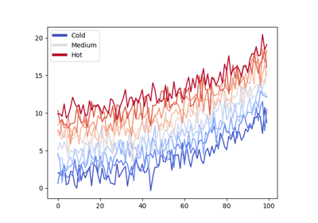

[Composing Custom Legends](https://matplotlib.org/3.1.1/gallery/text_labels_and_annotations/custom_legends.html#sphx-glr-gallery-text-labels-and-annotations-custom-legends-py)

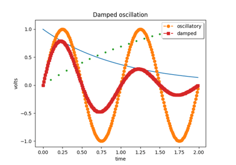

[Legend Demo](https://matplotlib.org/3.1.1/gallery/text_labels_and_annotations/legend_demo.html#sphx-glr-gallery-text-labels-and-annotations-legend-demo-py)

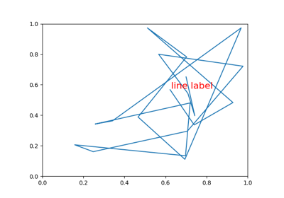

[Artist within an artist](https://matplotlib.org/3.1.1/gallery/text_labels_and_annotations/line_with_text.html#sphx-glr-gallery-text-labels-and-annotations-line-with-text-py)

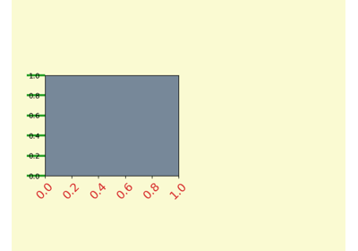

[Fig Axes Customize Simple](https://matplotlib.org/3.1.1/gallery/pyplots/fig_axes_customize_simple.html#sphx-glr-gallery-pyplots-fig-axes-customize-simple-py)

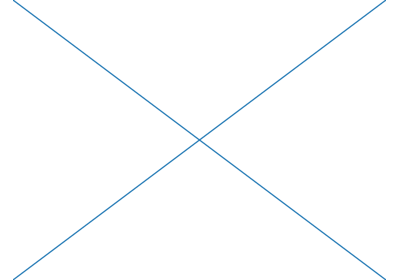

[Adding lines to figures](https://matplotlib.org/3.1.1/gallery/pyplots/fig_x.html#sphx-glr-gallery-pyplots-fig-x-py)

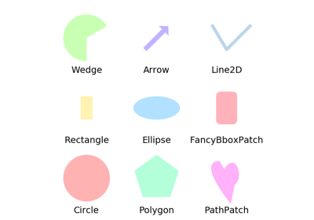

[Reference for Matplotlib artists](https://matplotlib.org/3.1.1/gallery/shapes_and_collections/artist_reference.html#sphx-glr-gallery-shapes-and-collections-artist-reference-py)

[figure not shown]

[Oscilloscope](https://matplotlib.org/3.1.1/gallery/animation/strip_chart.html#sphx-glr-gallery-animation-strip-chart-py)

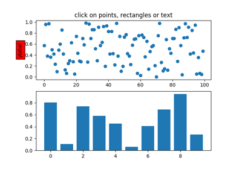

[Pick Event Demo](https://matplotlib.org/3.1.1/gallery/event_handling/pick_event_demo.html#sphx-glr-gallery-event-handling-pick-event-demo-py)

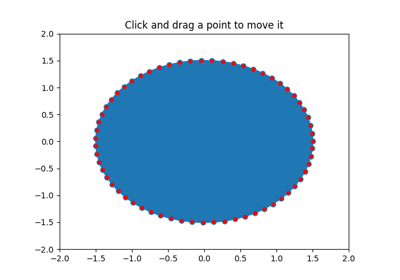

[Poly Editor](https://matplotlib.org/3.1.1/gallery/event_handling/poly_editor.html#sphx-glr-gallery-event-handling-poly-editor-py)

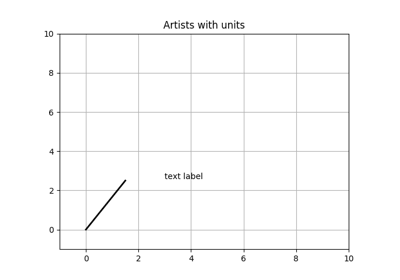

[Artist tests](https://matplotlib.org/3.1.1/gallery/units/artist_tests.html#sphx-glr-gallery-units-artist-tests-py)

[Pyplot tutorial](https://matplotlib.org/3.1.1/tutorials/introductory/pyplot.html#sphx-glr-tutorials-introductory-pyplot-py)

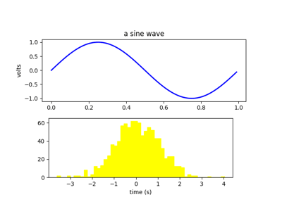

[Artist tutorial](https://matplotlib.org/3.1.1/tutorials/intermediate/artists.html#sphx-glr-tutorials-intermediate-artists-py)

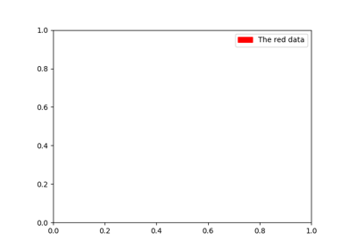

[Legend guide](https://matplotlib.org/3.1.1/tutorials/intermediate/legend_guide.html#sphx-glr-tutorials-intermediate-legend-guide-py)

© 2012–2018 Matplotlib Development Team. All rights reserved.  
Licensed under the Matplotlib License Agreement.  
https://matplotlib.org/3.1.1/api/_as_gen/matplotlib.lines.Line2D.html